# R Notebook

ELEC13: Percent vote for senators by province

prty13: Average share of votes (average percent of votes) for a senator in the party per province

ELEC19: Percent vote for senators by province

prty19: Average share of votes (average percent of votes) for a senator in the party per province

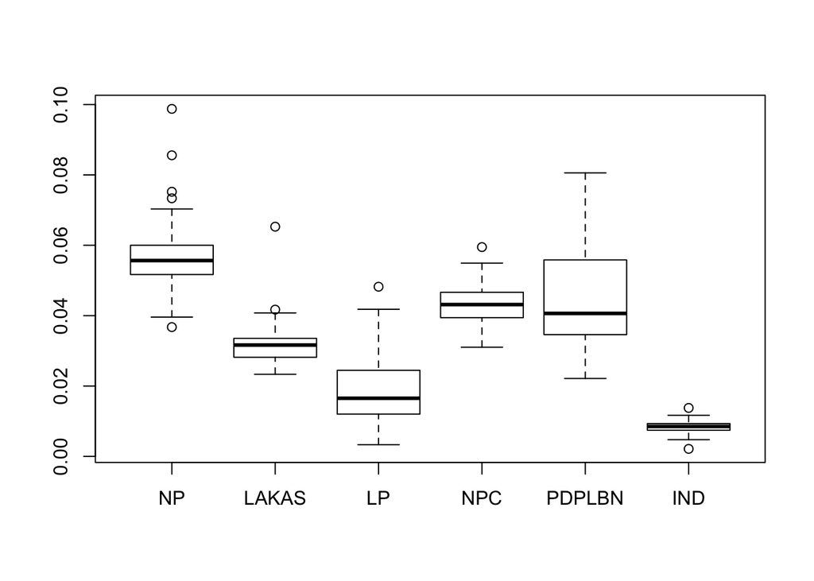

## Party Affiliation & Strength

### Did provinces support the same parties throughout 2013, 2016, 2019?

Plot of difference in average share of votes received by candidates in party X in a province of 2013 and 2019 (orange - NP, green - NPC, yellow - LP, blue - PDP)

```
## [1] 0.0202198
```

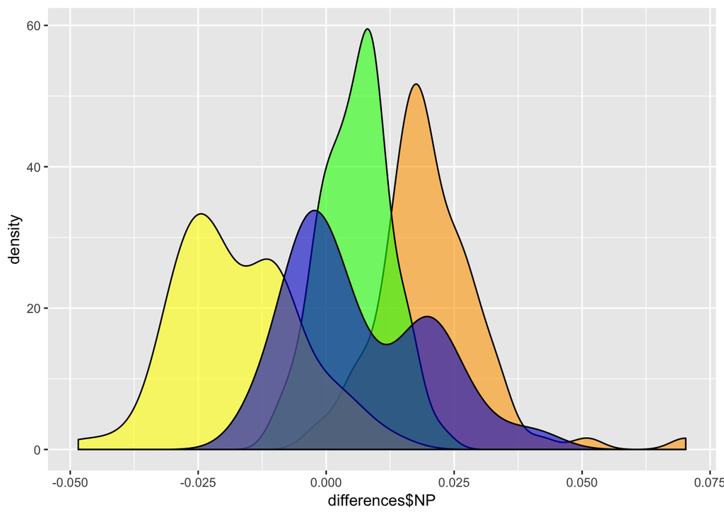

#### Which provinces voted for PDP Laban?

```
##  [1] AGUSAN DEL NORTE        BASILAN
##  [3] CAMIGUIN                COMPOSTELA VALLEY
##  [5] COTABATO (NORTH COT.)   DAVAO (DAVAO DEL NORTE)
##  [7] DAVAO OCCIDENTAL        DAVAO ORIENTAL
##  [9] LANAO DEL NORTE         LANAO DEL SUR
## [11] MAGUINDANAO             MISAMIS ORIENTAL
## [13] SARANGANI               SULU
## [15] SURIGAO DEL SUR         TAWI-TAWI
## [17] ZAMBOANGA DEL NORTE     ZAMBOANGA DEL SUR
## 84 Levels: ABRA AGUSAN DEL NORTE AGUSAN DEL SUR AKLAN ALBAY ... ZAMBOANGA SIBUGAY
```

pres16: Number of votes for president

vp16: Number of votes for vice president

#### Are they the same provinces that supported Duterte?

Provinces supporting Duterte in 2016 and PDP in 2019

```
##  [1] "AGUSAN DEL NORTE"        "BASILAN"
##  [3] "COMPOSTELA VALLEY"       "COTABATO (NORTH COT.)"
##  [5] "DAVAO (DAVAO DEL NORTE)" "DAVAO OCCIDENTAL"
##  [7] "DAVAO ORIENTAL"          "LANAO DEL NORTE"
##  [9] "LANAO DEL SUR"           "MAGUINDANAO"
## [11] "MISAMIS ORIENTAL"        "SARANGANI"
## [13] "SULU"                    "SURIGAO DEL SUR"
## [15] "TAWI-TAWI"               "ZAMBOANGA DEL NORTE"
## [17] "ZAMBOANGA DEL SUR"
```

Provinces voting Duterte in 2016 that didn’t vote PDP in 2019

```
##  [1] "ABRA"
##  [2] "AGUSAN DEL SUR"
##  [3] "BATAAN"
##  [4] "BATANGAS"
##  [5] "BILIRAN"
##  [6] "BOHOL"
##  [7] "BUKIDNON"
##  [8] "BULACAN"
##  [9] "CAVITE"
## [10] "CEBU"
## [11] "DAVAO DEL SUR"
## [12] "DINAGAT ISLANDS"
## [13] "ILOCOS NORTE"
## [14] "LAGUNA"
## [15] "LEYTE"
## [16] "MIDDLE EAST AND AFRICAS"
## [17] "NATIONAL CAPITAL REGION - FOURTH DISTRICT"
## [18] "NATIONAL CAPITAL REGION - MANILA"
## [19] "NATIONAL CAPITAL REGION - SECOND DISTRICT"
## [20] "NATIONAL CAPITAL REGION - THIRD DISTRICT"
## [21] "PALAWAN"
## [22] "PAMPANGA"
## [23] "RIZAL"
## [24] "SOUTH COTABATO"
## [25] "SOUTHERN LEYTE"
## [26] "SULTAN KUDARAT"
## [27] "SURIGAO DEL NORTE"
## [28] "TAGUIG - PATEROS"
## [29] "ZAMBOANGA SIBUGAY"
```

Provinces voting PDP in 2019 that didn’t vote Duterte in 2016

```
## [1] "CAMIGUIN"
```

#### Data Visualization

The average % of votes a candidate in a party received was calculated as

% votes received by party / # party members

I then took the difference of the average % of votes per candidate received in the 2013 and 2019 elections for NP, NPC, LP, and PDP-Laban parties. Positive values indicate that on the average, a candidate received more support from a particular province in 2019 than 2013, while a negative value meant it received less support.

The difference in average % of votes received candidate between 2013 and 2019 were then plotted by province.

Legend: * Yellow indicates high difference values (i.e. an average candidate in this party received more support in 2019 than 2013) * Red indicates low difference values (i.e. an average candidate in this party received little or even less support in 2019 than 2013)

[output not shown]

```
## Checking rgeos availability: TRUE
```

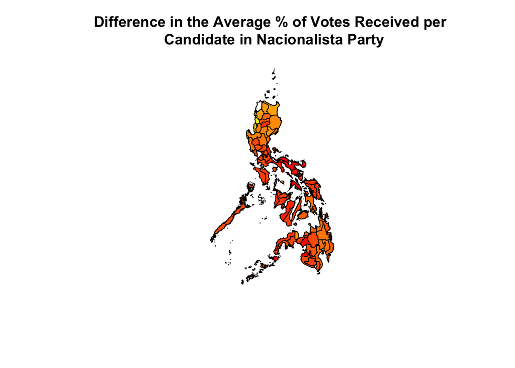

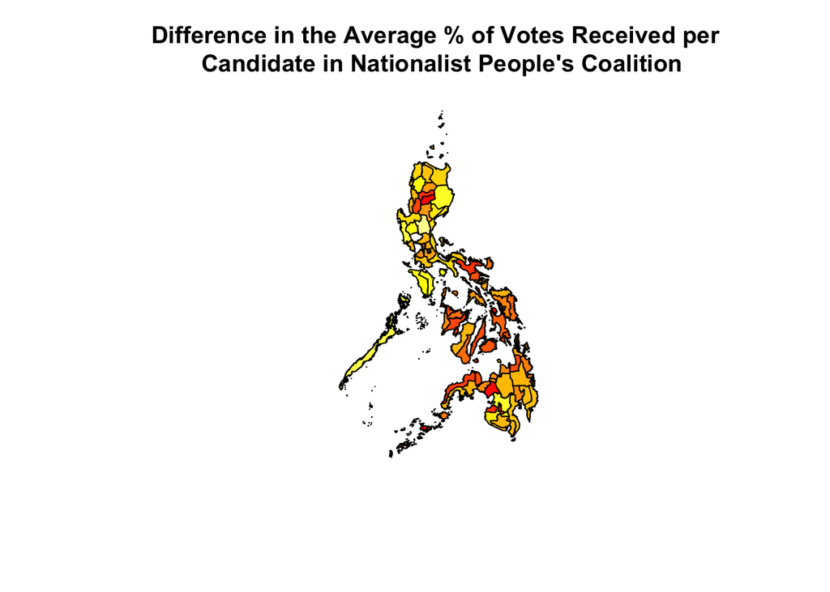

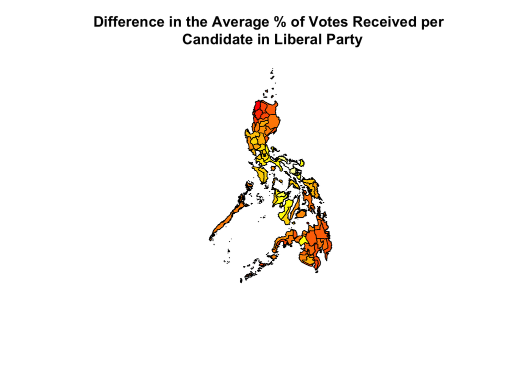

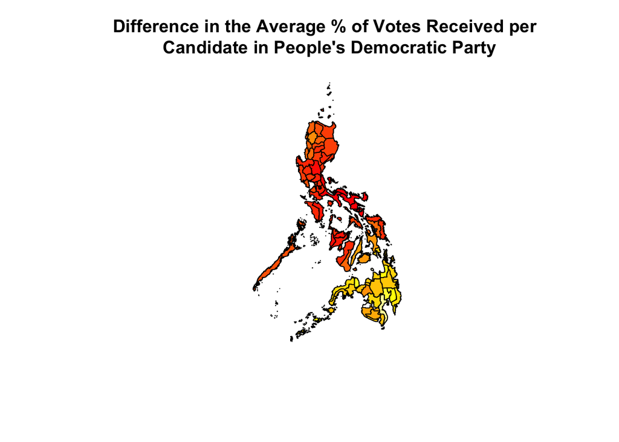

### Do members of the same party perform equally well?

Across 4 major parties, there is at least one member of the party who received a significantly different share of votes per province in comparison to the other members of the party at a significance level of 0.05.

```
##              Df  Sum Sq  Mean Sq F value Pr(>F)
## name          2 0.02852 0.014258   66.78 <2e-16 ***
## Residuals   249 0.05317 0.000214
## ---
## Signif. codes:  0 '***' 0.001 '**' 0.01 '*' 0.05 '.' 0.1 ' ' 1
```

```
##              Df   Sum Sq   Mean Sq F value   Pr(>F)
## name          1 0.002251 0.0022508   30.13 1.49e-07 ***
## Residuals   166 0.012402 0.0000747
## ---
## Signif. codes:  0 '***' 0.001 '**' 0.01 '*' 0.05 '.' 0.1 ' ' 1
```

```
##              Df  Sum Sq  Mean Sq F value Pr(>F)
## name          5 0.05218 0.010436   65.53 <2e-16 ***
## Residuals   498 0.07931 0.000159
## ---
## Signif. codes:  0 '***' 0.001 '**' 0.01 '*' 0.05 '.' 0.1 ' ' 1
```

```
##              Df  Sum Sq  Mean Sq F value Pr(>F)
## name          4 0.06875 0.017188   73.44 <2e-16 ***
## Residuals   415 0.09713 0.000234
## ---
## Signif. codes:  0 '***' 0.001 '**' 0.01 '*' 0.05 '.' 0.1 ' ' 1
```

```
##
##  Pairwise comparisons using t tests with pooled SD
##
## data:  NPsumm$votes and NPsumm$name
##
##                      CAYETANO..PIA..NP. MARCOS..IMEE..NP.
## MARCOS..IMEE..NP.    0.013              -
## VILLAR..CYNTHIA..NP. 1.5e-15            < 2e-16
##
## P value adjustment method: none
```

```
##
##  Pairwise comparisons using t tests with pooled SD
##
## data:  NPCsumm$votes and NPCsumm$name
##
##                   EJERCITO..ESTRADA.JV..NPC.
## LAPID..LITO..NPC. 1.5e-07
##
## P value adjustment method: none
```

```
##
##  Pairwise comparisons using t tests with pooled SD
##
## data:  LPsumm$votes and LPsumm$name
##
##                                ALEJANO..GARY..LP.
## AQUINO..BENIGNO.BAM...LP.      < 2e-16
## DIOKNO..CHEL..LP.              0.1382
## GUTOC..SAMIRA..LP.             0.9459
## ROXAS..MAR..LP.                5.8e-14
## TA.ADA.LORENZO.ERIN.TAPAT..LP. 0.1130
##                                AQUINO..BENIGNO.BAM...LP. DIOKNO..CHEL..LP.
## AQUINO..BENIGNO.BAM...LP.      -                         -
## DIOKNO..CHEL..LP.              < 2e-16                   -
## GUTOC..SAMIRA..LP.             < 2e-16                   0.1571
## ROXAS..MAR..LP.                1.3e-07                   8.8e-10
## TA.ADA.LORENZO.ERIN.TAPAT..LP. < 2e-16                   0.0022
##                                GUTOC..SAMIRA..LP. ROXAS..MAR..LP.
## AQUINO..BENIGNO.BAM...LP.      -                  -
## DIOKNO..CHEL..LP.              -                  -
## GUTOC..SAMIRA..LP.             -                  -
## ROXAS..MAR..LP.                9.2e-14            -
## TA.ADA.LORENZO.ERIN.TAPAT..LP. 0.0984             < 2e-16
##
## P value adjustment method: none
```

```
##
##  Pairwise comparisons using t tests with pooled SD
##
## data:  PDPsumm$votes and PDPsumm$name
##
##                             DELA.ROSA..BATO..PDPLBN. GO..BONG.GO..PDPLBN.
## GO..BONG.GO..PDPLBN.        0.022                    -
## MANGUDADATU..DONG..PDPLBN.  < 2e-16                  < 2e-16
## PIMENTEL..KOKO..PDPLBN.     6.7e-09                  2.7e-15
## TOLENTINO..FRANCIS..PDPLBN. 2.7e-07                  3.2e-13
##                             MANGUDADATU..DONG..PDPLBN.
## GO..BONG.GO..PDPLBN.        -
## MANGUDADATU..DONG..PDPLBN.  -
## PIMENTEL..KOKO..PDPLBN.     7.4e-13
## TOLENTINO..FRANCIS..PDPLBN. 6.5e-15
##                             PIMENTEL..KOKO..PDPLBN.
## GO..BONG.GO..PDPLBN.        -
## MANGUDADATU..DONG..PDPLBN.  -
## PIMENTEL..KOKO..PDPLBN.     -
## TOLENTINO..FRANCIS..PDPLBN. 0.491
##
## P value adjustment method: none
```